# Supervised Learning Text Complexity Classifier - POC

## POC notes

This version of the notebook using only the training csv and splits it into a train and test set. The best method found here will move to the Dev Notebook, where it will be trained using the whole train csv and the models will be output as pickles. Those pickles will then move Test Notebook where they will be used to generate predictions on the test csv.

## Data import and cleaning

Primary goals here are getting data from the training data set and creating metrics that will convey the complexity of the text to our classifiers. There are 3 additional data sources as part of the Kaggle set that we used. The average of acquisition data set contains information gathered on around 50,000 words and contains each words lemmatized root and information about when that word the average age a person learns that word and the frequency of its use. The concreteness ratings contains a smaller number of words, but gives an impression of how much a word is associated with a particular idea. Finally the dale_chall data set contains a list of words that are considered 'basic english'.

#### Dependencies

Below are the datacleaning dependencies only. A longer list of imports for modeling is at the start of that section.

```
import pandas as pd
import numpy as np
import re
import statistics as stats
from nltk.corpus import stopwords
from nltk.tokenize import word_tokenize
from nltk.corpus import wordnet
from nltk.stem import WordNetLemmatizer
from sklearn.feature_extraction.text import TfidfVectorizer
from sklearn.ensemble import GradientBoostingClassifier
from sklearn.ensemble import RandomForestClassifier
from sklearn.model_selection import train_test_split, GridSearchCV, cross_val_score
from sklearn.metrics import confusion_matrix, accuracy_score, precision_score
from sklearn.preprocessing import StandardScaler
from sklearn.svm import SVC
from sklearn.neighbors import KNeighborsClassifier
from sklearn.mixture import GaussianMixture
from sklearn.linear_model import LogisticRegression
from gensim.models.word2vec import Word2Vec
```

```
df = pd.read_csv('WikiLarge_Train.csv')
```

#### Control of how much data we train with

```
df_shuffle = df.sample(frac = 1)
df_train = df_shuffle.head(333414).copy() #for final run through
#df_train = df_shuffle.head(20000).copy()

df_test = df_shuffle.tail(83354).copy() #for final run through
#df_test = df_shuffle.tail(20000).copy()
```

# Train Data

### Word Tokenization and Stop Word Removal

Metrics are created out of the word count and the syllable counts within the text. However, stop words are common and often only one syllable so they were removed. The metrics will therefore be based only on the remaining words. This will through off the flesch_kincaid score from what it might have been calculated, but when trying to predict text complexity, stop words can be noisy and non-informative.

```
def tokenize_and_remove_stops(text):
    text_list = word_tokenize(text)
    stop_word_set = set(stopwords.words('english'))
    clean_list = [word.lower() for word in text_list if word.lower() not in stop_word_set]
    clean_list = [word for word in clean_list if re.match('^[a-z]+$', word)]

    return clean_list
```

```
df_train['clean_text'] = df_train['original_text'].apply(tokenize_and_remove_stops)

df_train.head()
```

|  | original_text | label | clean_text |
| --- | --- | --- | --- |
| 214899 | As a form of entertainment , the mechanical bu... | 0 | [form, entertainment, mechanical, bull, often,... |
| 318453 | The 1912 Summer Olympics , officially known as... | 0 | [summer, olympics, officially, known, games, v... |
| 174480 | ISBN 1-85437-513-X Delacroix 's use of express... | 1 | [isbn, delacroix, use, expressive, brushstroke... |
| 219006 | Joe Kinnear is a former football player . | 0 | [joe, kinnear, former, football, player] |
| 94970 | 1930 & ndash ; Mahatma Gandhi leads a 200-mile... | 1 | [ndash, mahatma, gandhi, leads, march, known, ... |

#### Syllable count

While the age of acquisition data source has a syllable count attached to each word, it remains the case that not all words in the texts were in that data source. This syllable counter was retrieved from stack overflow and validated.

```
def syllable_count(clean_text_list):
    count = 0
    for word in clean_text_list:
        word = word.lower()
        vowels = "aeiouy"
        if word[0] in vowels:
            count += 1
        for index in range(1, len(word)):
            if word[index] in vowels and word[index - 1] not in vowels:
                count += 1
        if word.endswith("e"):
            count -= 1
        if count == 0:
            count += 1
    return count
```

```
df_train['syllables'] = df_train['clean_text'].apply(syllable_count)
df_train['word_count'] = df_train['clean_text'].apply(lambda x: len(x))
df_train['avg_syll_per_word'] = df_train['syllables'] / df_train['word_count']
df_train['avg_syll_per_word'] = df_train['avg_syll_per_word'].fillna(0)

df_train.head()
```

|  | original_text | label | clean_text | syllables | word_count | avg_syll_per_word |
| --- | --- | --- | --- | --- | --- | --- |
| 214899 | As a form of entertainment , the mechanical bu... | 0 | [form, entertainment, mechanical, bull, often,... | 36 | 20 | 1.800000 |
| 318453 | The 1912 Summer Olympics , officially known as... | 0 | [summer, olympics, officially, known, games, v... | 20 | 10 | 2.000000 |
| 174480 | ISBN 1-85437-513-X Delacroix 's use of express... | 1 | [isbn, delacroix, use, expressive, brushstroke... | 46 | 19 | 2.421053 |
| 219006 | Joe Kinnear is a former football player . | 0 | [joe, kinnear, former, football, player] | 8 | 5 | 1.600000 |
| 94970 | 1930 & ndash ; Mahatma Gandhi leads a 200-mile... | 1 | [ndash, mahatma, gandhi, leads, march, known, ... | 30 | 16 | 1.875000 |

#### Flesch_kincaid ease

```
def flesch_kincaid_ease(row):
    return round(206.835 - 1.015*(row['word_count']) - 84.6*(row['avg_syll_per_word']),2)
```

```
df_train['fc_ease'] = df_train.apply(flesch_kincaid_ease, axis = 1)

fc_mean = df_train['fc_ease'].dropna().mean()
df_train['fc_ease'] = df_train['fc_ease'].fillna(fc_mean)

df_train.head()
```

|  | original_text | label | clean_text | syllables | word_count | avg_syll_per_word | fc_ease |
| --- | --- | --- | --- | --- | --- | --- | --- |
| 214899 | As a form of entertainment , the mechanical bu... | 0 | [form, entertainment, mechanical, bull, often,... | 36 | 20 | 1.800000 | 34.26 |
| 318453 | The 1912 Summer Olympics , officially known as... | 0 | [summer, olympics, officially, known, games, v... | 20 | 10 | 2.000000 | 27.49 |
| 174480 | ISBN 1-85437-513-X Delacroix 's use of express... | 1 | [isbn, delacroix, use, expressive, brushstroke... | 46 | 19 | 2.421053 | -17.27 |
| 219006 | Joe Kinnear is a former football player . | 0 | [joe, kinnear, former, football, player] | 8 | 5 | 1.600000 | 66.40 |
| 94970 | 1930 & ndash ; Mahatma Gandhi leads a 200-mile... | 1 | [ndash, mahatma, gandhi, leads, march, known, ... | 30 | 16 | 1.875000 | 31.97 |

Quick check to see if there is a difference between the two labels on this metric.

```
df_train.groupby('label')['fc_ease'].mean()
```

```
label
0    25.679761
1    15.755495
Name: fc_ease, dtype: float64
```

#### Concreteness Ratings

The cell below reads the concreteness data source and converts it into a dictionary with the word as the key and the measure values as entries in a nested dictionary. This allows me to calculate averages for a given text.

```
df_conc = pd.read_csv('Concreteness_ratings_Brysbaert_et_al_BRM.txt', sep = '\t').fillna('0')
basic_list = pd.read_csv('dale_chall.txt')['a'].to_list()


df_conc['non_basic'] = df_conc['Word'].apply(lambda x: 0 if x in basic_list else 1)
mean_conc = round(df_conc['Conc.M'].mean(), 4)
print(df_conc.head(1))
print(mean_conc)

conc_keys = df_conc['Word'].tolist()

dict_list = df_conc.set_index('Word').to_dict(orient = 'records')

conc_dict = {}

for i in range(len(conc_keys)):
    conc_dict[conc_keys[i]] = dict_list[i]
```

```
          Word  Bigram  Conc.M  Conc.SD  Unknown  Total  Percent_known  \
0  roadsweeper       0    4.85     0.37        1     27           0.96

   SUBTLEX Dom_Pos  non_basic
0        0       0          1
3.0363
```

#### Age of Acquisition

Similar to the concreteness data set, the cell below gets the desired measures from the AoA data source into a dictionary for use in the metric calculations. Slightly different is that the AoA data source also has a column for alternative spellings. If the alternative spelling listed is different then the primary spelling, that spelling is added to the final dictionary as a unique entry.

```
df_age = pd.read_csv('AoA_51715_words.csv')
df_age['non_basic'] = df_age['Lemma_highest_PoS'].apply(lambda x: 0 if x in basic_list else 1)
#print(df_age.head())

mean_aoa = round(df_age['AoA_Kup_lem'].mean(), 4)
mean_perc_known = round(df_age['Perc_known_lem'].mean(),4)
med_freq = df_age['Freq_pm'].median()

#print(mean_aoa, mean_perc_known, med_freq)

age_keys = df_age['Word'].to_list()
age_alt_keys = df_age['Alternative.spelling'].to_list()

df_columns_for_dict = df_age[['Freq_pm', 'Dom_PoS_SUBTLEX', 'AoA_Kup_lem', 'Perc_known_lem', 'non_basic']].copy()
df_columns_for_dict.columns = ['freq', 'pos', 'aoa', 'perc_known', 'non_basic']
dict_list = df_columns_for_dict.to_dict(orient = 'records')


age_dict = {}
for i in range(len(age_keys)):
    age_dict[age_keys[i]] = dict_list[i]

for i in range(len(age_alt_keys)):
    if age_alt_keys[i] not in age_dict:
        age_dict[age_alt_keys[i]] = dict_list[i]
```

```
#round(np.mean([age_dict[key]['aoa'] for key in age_dict]), 4)
print(mean_aoa)
print(mean_perc_known)
print(med_freq)
```

```
10.3615
0.9037
0.27
```

#### Metric calcuations

The goal of the functions below is to get the average entry for each clean text entry in df_train. The percent_known is located in both data sources, so the larger data source (age of acquisition) is checked first. Frequency has a such heavy outliers on the high end, that median was selected instead of mean. If a word cannot be found the means of the features are substituted (median for frequency).

```
def get_mean_conc(text):
    sum_conc = 0
    word_count = max(len(text), 1)
    for word in text:
        try:
            sum_conc += conc_dict[word]['Conc.M']
        except:
            sum_conc += mean_conc

    return round(sum_conc / word_count, 4)

def get_mean_aoa(text):
    sum_aoa = 0
    word_count = max(len(text), 1)
    for word in text:
        try:
            sum_aoa += age_dict[word]['aoa']
        except:
            sum_aoa += mean_aoa

    return round(sum_aoa / word_count, 4)

def get_mean_perc(text):
    sum_perc = 0
    word_count = max(len(text), 1)
    for word in text:
        try:
            sum_perc += age_dict[word]['perc_known']
        except:
            try:
                sum_perc += conc_dict[word]['Percent_known']
            except:
                sum_perc += mean_perc_known

    return round(sum_perc / word_count, 4)

def get_mean_freq(text):
    list_freq = []
    for word in text:
        try:
            list_freq.append(age_dict[word]['freq'])
        except:
            list_freq.append(med_freq)

    if not list_freq:
        list_freq.append(0)

    return stats.median(list_freq)

def count_non_basic(text):
    count = 0
    for word in text:
        try:
            count += age_dict[word]['non_basic']
        except:
            try:
                count += conc_dict[word]['non_basic']
            except:
                count += 1
    return count
```

```
df_train['mean_conc'] = df_train['clean_text'].apply(get_mean_conc)
df_train['mean_aoa'] = df_train['clean_text'].apply(get_mean_aoa)
df_train['mean_perc_known'] = df_train['clean_text'].apply(get_mean_perc)
df_train['mean_freq'] = df_train['clean_text'].apply(get_mean_freq)
df_train['non_basic_words'] = df_train['clean_text'].apply(count_non_basic)
df_train = df_train.fillna(0)
#df_train.replace([np.inf, -np.inf], np.nan).isnull().sum() #sanity check for nulls or infs

#df_train.head()
```

### Tfidf Logistic Regression Probablity

The goal here is to train a logistic regresssion classifier on the tfidf vectors of the lemmatized words remaining in the cleaned text. Once trained, it will be used to predict the probability of the class. This probablity will be used as a feature along with other text based features calculated below.

```
def lem_combine(text_list):
    lem = WordNetLemmatizer()
    lem_word = []
    for word in text_list:
        lem_word.append(lem.lemmatize(word))

    return (' '.join(word for word in lem_word))
```

```
df_train['lem_text'] = df_train['clean_text'].apply(lem_combine)
```

```
### Training and test for proof of concept

# vectorizer = TfidfVectorizer(stop_words = 'english', ngram_range = (1,3), max_features = 30000)

# X_vec = vectorizer.fit_transform(df_train['lem_text'])
# y_vec = df_train['label']

# log_vec = LogisticRegression(max_iter = 1000)
# log_vec.fit(X_v_train, y_v_train)
```

```
### Train on full data since the test csv will eventually be used for testing

vectorizer = TfidfVectorizer(stop_words = 'english', ngram_range = (1,3), max_features = 30000)

X_vec = vectorizer.fit_transform(df_train['lem_text'])
y_vec = df_train['label']

log_vec = LogisticRegression(max_iter = 1000)
log_vec.fit(X_vec, y_vec)
```

```
LogisticRegression(max_iter=1000)
```

```
preds = np.array([nums[0] for nums in log_vec.predict_proba(X_vec)])

df_train['log_reg_prob'] = preds

df_train.head()
```

|  | original_text | label | clean_text | syllables | word_count | avg_syll_per_word | fc_ease | mean_conc | mean_aoa | mean_perc_known | mean_freq | non_basic_words | lem_text | log_reg_prob |
| --- | --- | --- | --- | --- | --- | --- | --- | --- | --- | --- | --- | --- | --- | --- |
| 214899 | As a form of entertainment , the mechanical bu... | 0 | [form, entertainment, mechanical, bull, often,... | 36 | 20 | 1.800000 | 34.26 | 3.3989 | 5.9130 | 1.0000 | 32.03 | 5 | form entertainment mechanical bull often inclu... | 0.564103 |
| 318453 | The 1912 Summer Olympics , officially known as... | 0 | [summer, olympics, officially, known, games, v... | 20 | 10 | 2.000000 | 27.49 | 2.9408 | 7.7878 | 0.9615 | 2.26 | 6 | summer olympics officially known game v olympi... | 0.768960 |
| 174480 | ISBN 1-85437-513-X Delacroix 's use of express... | 1 | [isbn, delacroix, use, expressive, brushstroke... | 46 | 19 | 2.421053 | -17.27 | 2.7727 | 8.4319 | 0.9814 | 6.00 | 13 | isbn delacroix use expressive brushstrokes stu... | 0.297904 |
| 219006 | Joe Kinnear is a former football player . | 0 | [joe, kinnear, former, football, player] | 8 | 5 | 1.600000 | 66.40 | 3.4265 | 8.1806 | 0.9615 | 18.27 | 3 | joe kinnear former football player | 0.947937 |
| 94970 | 1930 & ndash ; Mahatma Gandhi leads a 200-mile... | 1 | [ndash, mahatma, gandhi, leads, march, known, ... | 30 | 16 | 1.875000 | 31.97 | 3.1965 | 8.5437 | 0.9639 | 2.90 | 10 | ndash mahatma gandhi lead march known dandi ma... | 0.127109 |

### Word2Vec - Document Mean Vector

```
df_train.head()
```

|  | original_text | label | clean_text | syllables | word_count | avg_syll_per_word | fc_ease | mean_conc | mean_aoa | mean_perc_known | mean_freq | non_basic_words | lem_text | log_reg_prob |
| --- | --- | --- | --- | --- | --- | --- | --- | --- | --- | --- | --- | --- | --- | --- |
| 214899 | As a form of entertainment , the mechanical bu... | 0 | [form, entertainment, mechanical, bull, often,... | 36 | 20 | 1.800000 | 34.26 | 3.3989 | 5.9130 | 1.0000 | 32.03 | 5 | form entertainment mechanical bull often inclu... | 0.564103 |
| 318453 | The 1912 Summer Olympics , officially known as... | 0 | [summer, olympics, officially, known, games, v... | 20 | 10 | 2.000000 | 27.49 | 2.9408 | 7.7878 | 0.9615 | 2.26 | 6 | summer olympics officially known game v olympi... | 0.768960 |
| 174480 | ISBN 1-85437-513-X Delacroix 's use of express... | 1 | [isbn, delacroix, use, expressive, brushstroke... | 46 | 19 | 2.421053 | -17.27 | 2.7727 | 8.4319 | 0.9814 | 6.00 | 13 | isbn delacroix use expressive brushstrokes stu... | 0.297904 |
| 219006 | Joe Kinnear is a former football player . | 0 | [joe, kinnear, former, football, player] | 8 | 5 | 1.600000 | 66.40 | 3.4265 | 8.1806 | 0.9615 | 18.27 | 3 | joe kinnear former football player | 0.947937 |
| 94970 | 1930 & ndash ; Mahatma Gandhi leads a 200-mile... | 1 | [ndash, mahatma, gandhi, leads, march, known, ... | 30 | 16 | 1.875000 | 31.97 | 3.1965 | 8.5437 | 0.9639 | 2.90 | 10 | ndash mahatma gandhi lead march known dandi ma... | 0.127109 |

```
w2v = Word2Vec(df_train['lem_text'].apply(lambda x: x.split()))


def document_vector(text):
    doc = [word for word in text.split() if word in w2v.wv.vocab]
    if len(doc) == 0:
        doc.append('pass')
    return np.mean(w2v[doc])

df_train['w2v'] = df_train.lem_text.apply(document_vector)
```

#### Final X and y for models

Below is a list of the columns being used to make X and y.

```
X_train = df_train[['word_count', 'avg_syll_per_word', 'fc_ease', 'mean_conc', 'mean_aoa', 'mean_perc_known', 'mean_freq', 'non_basic_words', 'log_reg_prob', 'w2v']]
y_train = df_train['label']
```

#### Grid search and score

This function accepts a parameter grid for a given algorithm and returns both the best parameter combination as well as the best score. It was used to help tune the various algorithms on the partial data set, and to a much lesser extend to fine tune them on the full data set.

```
# rfc_parameters = {
#     'n_estimators' : [200, 500], #default 100
#     #'max_features' : ['sqrt', 'log2'], #default is 'auto' which is actually sqrt
#     #'min_samples_split' : [0.005, 0.01, 0.05],
#     'min_samples_leaf': [0.005, 1],
#     'max_depth':[5, 10, 20]
# }

# def grid_search_and_score(model, parameters):
#     clf = GridSearchCV(model, parameters, n_jobs = 3, scoring = 'accuracy', cv = 5)
#     clf.fit(X, y)
#     print(clf.best_score_)
#     print(clf.best_params_)
#     return clf

# grid_search_and_score(RandomForestClassifier(), rfc_parameters)

#yields {'max_depth': 20, 'min_samples_leaf': 1, 'n_estimators': 500}
```

#### Gradient Boosting Forest Classifier

```
# gb_clf = GradientBoostingClassifier(learning_rate = 0.05, n_estimators = 500)
# gb_clf.fit(X_train, y_train)
```

#### Random Forest Classifier (high performer)

```
#np.mean(cross_val_score(RandomForestClassifier(max_depth = 20, min_samples_leaf = 1, n_estimators = 500),X = X, y = y,  n_jobs = 3))

# rf_clf = RandomForestClassifier(max_depth = 20, min_samples_leaf = 1, n_estimators = 500)
# rf_clf.fit(X_train, y_train)
```

#### SVC

While a support vector machine with a linear kernel had a decent score on the sample data set, it was not one of the front runners. Once the full data set was evaluated this method was abandoned not just based on the score, but also on the resource required to train it.

```
scaler = StandardScaler()
scaler.fit(X_train)
X_train_scaled = scaler.transform(X_train)

##########################################
#### Too Long When Using Full Data Set ###
####  But it wasn't very good anyway  ####
##########################################

# svc_clf = SVC(kernel = 'linear')
# svc_clf.fit(X_train_scaled, y_train)

###########################################
```

#### K Nearest Neighbors (high performer)

With some parameter tuning, this performed equivalent to the random forest classifier. The two appear to be apprimately equivalent.

```
knn_clf = KNeighborsClassifier(n_neighbors =100, weights = 'distance', p = 2)
knn_clf.fit(X_train_scaled, y_train)
```

```
KNeighborsClassifier(n_neighbors=100, weights='distance')
```

### Gaussian Mixtrue Model

Consistently worse than a dummy classifier.

```
# gm_clf = GaussianMixture()
# gm_clf.fit(X_train_scaled, y_train)
```

#### Logistic Regression

While an LR classifier performs a little over 68 percent on the Kaggle leaderboard, with the metrics created in this workbook, it was unable to achieve that score.

```
# log_clf = LogisticRegression(max_iter = 1000, C = 1)
# log_clf.fit(X_train, y_train)
```

# Test Data

Using the models and steps articulated above, we will try to predict the test data now. This again is not the true test data, just a held out sample of our training data.

```
df_test['clean_text'] = df_test['original_text'].apply(tokenize_and_remove_stops)

df_test.dtypes
```

```
original_text    object
label             int64
clean_text       object
dtype: object
```

```
df_test['syllables'] = df_test['clean_text'].apply(syllable_count)
df_test['word_count'] = df_test['clean_text'].apply(lambda x: len(x))
df_test['avg_syll_per_word'] = df_test['syllables'] / df_test['word_count']
df_test['avg_syll_per_word'] = df_test['avg_syll_per_word'].fillna(0)

df_test.head()
```

|  | original_text | label | clean_text | syllables | word_count | avg_syll_per_word |
| --- | --- | --- | --- | --- | --- | --- |
| 268134 | Frederick Aaron Savage -LRB- born July 9 , 197... | 0 | [frederick, aaron, savage, born, july, emmy, a... | 30 | 13 | 2.307692 |
| 74622 | Donahue arrived in January 1825 with 200 other... | 1 | [donahue, arrived, january, convicts, assigned... | 28 | 13 | 2.153846 |
| 372502 | Until recently , V10s had rarely used for road... | 0 | [recently, rarely, used, road, cars] | 10 | 5 | 2.000000 |
| 84250 | Bertogne is a municipality of Belgium . | 1 | [bertogne, municipality, belgium] | 10 | 3 | 3.333333 |
| 354795 | The current mayor of Waveland is Democrat Tomm... | 0 | [current, mayor, waveland, democrat, tommy, lo... | 13 | 6 | 2.166667 |

```
df_test['fc_ease'] = df_test.apply(flesch_kincaid_ease, axis = 1)

fc_mean = df_test['fc_ease'].dropna().mean()
df_test['fc_ease'] = df_test['fc_ease'].fillna(fc_mean)

df_test.head()
```

|  | original_text | label | clean_text | syllables | word_count | avg_syll_per_word | fc_ease |
| --- | --- | --- | --- | --- | --- | --- | --- |
| 268134 | Frederick Aaron Savage -LRB- born July 9 , 197... | 0 | [frederick, aaron, savage, born, july, emmy, a... | 30 | 13 | 2.307692 | -1.59 |
| 74622 | Donahue arrived in January 1825 with 200 other... | 1 | [donahue, arrived, january, convicts, assigned... | 28 | 13 | 2.153846 | 11.42 |
| 372502 | Until recently , V10s had rarely used for road... | 0 | [recently, rarely, used, road, cars] | 10 | 5 | 2.000000 | 32.56 |
| 84250 | Bertogne is a municipality of Belgium . | 1 | [bertogne, municipality, belgium] | 10 | 3 | 3.333333 | -78.21 |
| 354795 | The current mayor of Waveland is Democrat Tomm... | 0 | [current, mayor, waveland, democrat, tommy, lo... | 13 | 6 | 2.166667 | 17.45 |

```
df_test['mean_conc'] = df_test['clean_text'].apply(get_mean_conc)
df_test['mean_aoa'] = df_test['clean_text'].apply(get_mean_aoa)
df_test['mean_perc_known'] = df_test['clean_text'].apply(get_mean_perc)
df_test['mean_freq'] = df_test['clean_text'].apply(get_mean_freq)
df_test['non_basic_words'] = df_test['clean_text'].apply(count_non_basic)
df_test = df_test.fillna(0)
```

```
df_test['lem_text'] = df_test['clean_text'].apply(lem_combine)
```

```
X_vec = vectorizer.transform(df_test['lem_text'])
y_vec = df_test['label']

preds = log_vec.predict(X_vec)
print(accuracy_score(preds, y_vec))

df_test['logreg_prob'] = [num[0] for num in log_vec.predict_proba(X_vec)]
```

```
0.6790555942126353
```

```
df_test['w2v'] = df_test.lem_text.apply(document_vector)
```

```
X_test = df_test[['word_count', 'avg_syll_per_word', 'fc_ease', 'mean_conc', 'mean_aoa', 'mean_perc_known', 'mean_freq', 'non_basic_words', 'logreg_prob', 'w2v']]
y_test = df_test['label']
```

```
scaler_test = StandardScaler()
scaler_test.fit(X_test)
X_test_scaled = scaler_test.transform(X_test)
```

```
# y_gb_pred = gb_clf.predict(X_test)
# accuracy_score(y_gb_pred, y_test)
```

```
# y_rf_pred = rf_clf.predict(X_test)
# accuracy_score(y_rf_pred, y_test)
```

```
y_knn_pred = knn_clf.predict(X_test_scaled)
accuracy_score(y_knn_pred, y_test)
```

```
0.7132591117402884
```

```
# y_gm_pred = gm_clf.predict(X_test_scaled)
# accuracy_score(y_gm_pred, y_test)
```

```
# y_log_pred = log_clf.predict(X_test_scaled)
# accuracy_score(y_log_pred, y_test)
```

```
# rf_clf.feature_importances_
```

```
# df_train.head()
```

```
import matplotlib.pyplot as plt
import seaborn as sns
sns.set()

feats = X_train.columns
fig, ax = plt.subplots(4, 3, figsize = (20, 18))
fig.delaxes(ax[3][2])
fig.delaxes(ax[3][1])
axes = ax.ravel()
axes = axes[:-2]
for i in range(len(feats)):
    sns.violinplot(y_train, X_train[feats[i]], ax = axes[i])
    axes[i].set_ylabel(feats[i], fontsize = 20)
    axes[i].get_xaxis().set_visible(False)
    if i == 5:
        axes[i].set_ylim(0.8, 1.05)
    elif i == 6:
        axes[i].set_yscale('log')

plt.suptitle('Density Distrubiton of Features Between Classes', y = 1.01, fontsize = 22)
plt.tight_layout()
plt.show
```

```
<function matplotlib.pyplot.show(*args, **kw)>
```

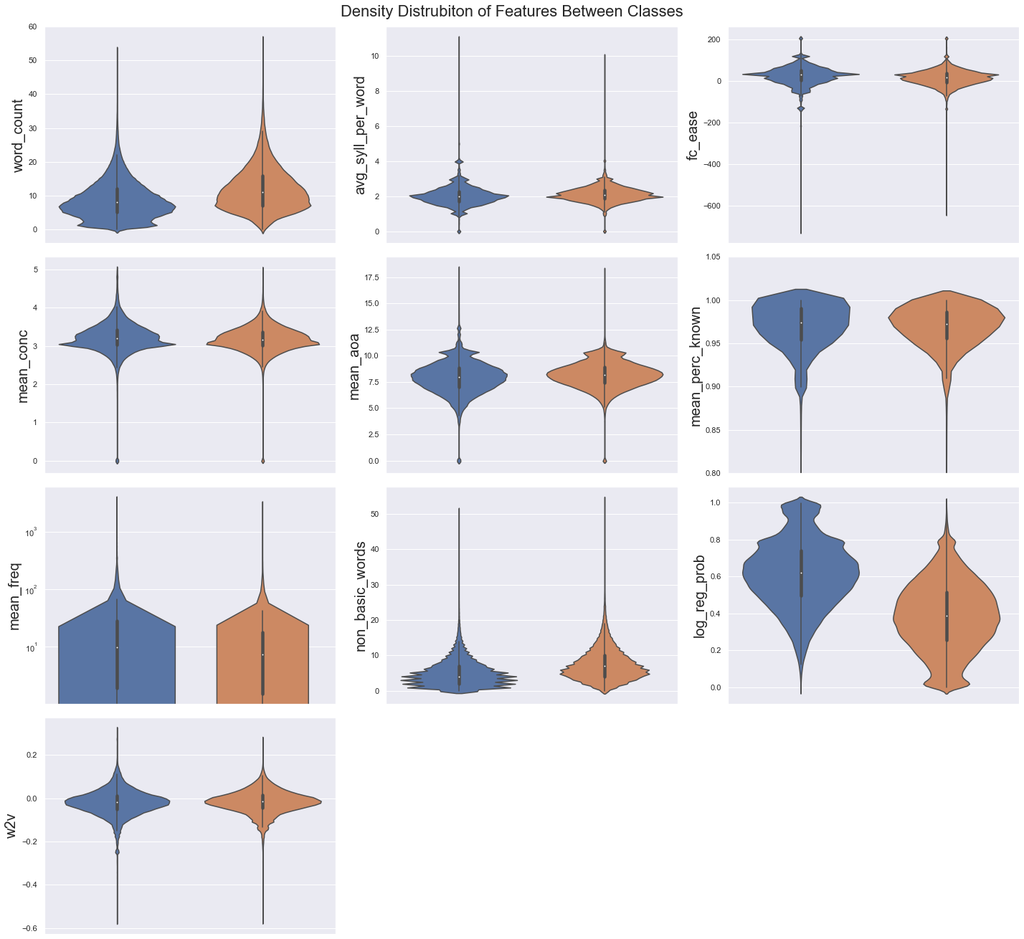

```
test_dic = {'word_count': df_test['word_count'].tolist()
           ,'prediction' : y_knn_pred.tolist()
           ,'actual' : y_test.tolist()}

df_word_count = pd.DataFrame(test_dic)
df_word_count['accurate?'] = df_word_count.apply(lambda x: 1 if x['prediction'] == x['actual'] else 0, axis = 1)
df_word_count['npv'] = df_word_count.apply(lambda x: 1 if x['actual'] == 0 and x['prediction'] == 0 else (None if x['actual'] == 1 else 0), axis = 1)

df_viz = (df_word_count.groupby('word_count')
          .agg({'accurate?' : ['count','mean']
         ,'npv' : ['count','mean']})
          .reset_index())
df_viz.columns = ['word_count', 'texts', 'accuracy', 'predicted_simple', 'recall']
df_viz = df_viz[df_viz['predicted_simple'] >= 100]


fig, ax = plt.subplots(figsize = (20, 9))
sns.lineplot(data = df_viz, x = 'word_count', y = 'recall', ax = ax)
ax.set_ylabel('Recall' ,fontsize = 18)
ax.set_xlabel('Word Count', fontsize = 18)
plt.suptitle('Recall of Simple Sentences by Word Count', y = 0.95, fontsize = 22)
```

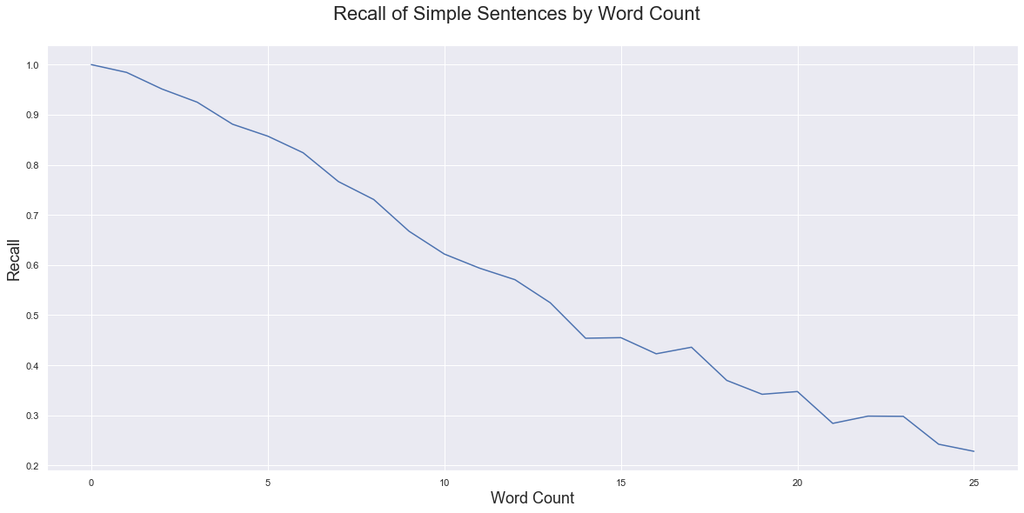